# Entregable 1

Hecho por: A00227714 José Miguel Beltrán Cinco

```r
library(seqinr)
library(ggplot2)
library(reshape2)
```

Se presentan las lecturas y datos básicos de cada secuencia, en orden:

-La cantidad de nucleotidos A,C,G y Y que la componen. -El porcentaje de los nucleotidos que la componen. -La longitud de la secuencia Y -El porcentaje de nucleotidos CG que la componen. -Y los primeros 15 nucleotidos de la secuencia con los últimos 15 nucleotidos despues de invertirse.

Variante Cero (WIV04/2019) https://www.ncbi.nlm.nih.gov/nuccore/1802633808

```r
sars <- read.fasta(file = 'sars_2.fasta', as.string = TRUE, seqonly = TRUE)

sars <- unlist(sars)
sars <- strsplit(sars, "")
sars <- unlist(sars)

length_sars <- length(sars)
cat("La longitud es: \n",length_sars,'\n')
```

```
La longitud es:
 29891
```

```r
sars_data <- table(sars)
cat("\nLa cantidad de nucleotidos de cada tipo es: \n")
```

```
La cantidad de nucleotidos de cada tipo es:
```

```r
sars_data
```

```
sars
   A    C    G    T
8942 5492 5863 9594
```

```r
sars_data_porcentajes <- (sars_data/length_sars)*100
cat("\nEl porcentaje de nucleotidos de cada tipo es: \n")
```

```
El porcentaje de nucleotidos de cada tipo es:
```

```r
sars_data_porcentajes
```

```
sars
       A        C        G        T
29.91536 18.37342 19.61460 32.09662
```

```r
gc_sars <- (sum(sars_data[2],sars_data[3])/length_sars)*100
cat("\nEl porcentaje de GC es: \n")
```

```
El porcentaje de GC es:
```

```r
gc_sars
```

```
[1] 37.98802
```

```r
rev_sars <- rev(sars)
cat("\nLos primeros 15 nucleotidos de la secuencia y los ultimos 15 nucleotidos despues de invertirse son: \n")
```

```
Los primeros 15 nucleotidos de la secuencia y los ultimos 15 nucleotidos despues de invertirse son:
```

```r
sars[1:15]
```

```
 [1] "A" "T" "T" "A" "A" "A" "G" "G" "T" "T" "T" "A" "T" "A" "C"
```

```r
rev_sars[(length_sars-14):length_sars]
```

```
 [1] "C" "A" "T" "A" "T" "T" "T" "G" "G" "A" "A" "A" "T" "T" "A"
```

Variante de Brasil (P.1)https://www.ncbi.nlm.nih.gov/nuccore/MW642250.1

```r
sars_brazil <- read.fasta(file = 'sars_brazil.fasta', as.string = TRUE, seqonly = TRUE)

sars_brazil <- unlist(sars_brazil)
sars_brazil <- strsplit(sars_brazil, "")
sars_brazil <- unlist(sars_brazil)

sars_brazil <- sars_brazil[-which(sars_brazil=='M')]

length_sars_brazil <- length(sars_brazil)
cat("La longitud es: \n",length_sars,'\n')
```

```
La longitud es:
 29891
```

```r
length_sars_brazil
```

```
[1] 29858
```

```r
sars_brazil_data <- table(sars_brazil)
cat("\nLa cantidad de nucleotidos de cada tipo es: \n")
```

```
La cantidad de nucleotidos de cada tipo es:
```

```r
sars_brazil_data
```

```
sars_brazil
   A    C    G    T
8917 5482 5855 9604
```

```r
sars_brazil_data_porcentajes <- (sars_brazil_data/length_sars_brazil)*100
cat("\nEl porcentaje de nucleotidos de cada tipo es: \n")
```

```
El porcentaje de nucleotidos de cada tipo es:
```

```r
sars_brazil_data_porcentajes
```

```
sars_brazil
       A        C        G        T
29.86469 18.36024 19.60948 32.16558
```

```r
gc_brazil <- (sum(sars_brazil_data[2],sars_brazil_data[3])/length_sars_brazil)*100
cat("\nEl porcentaje de GC es: \n")
```

```
El porcentaje de GC es:
```

```r
gc_brazil
```

```
[1] 37.96972
```

```r
rev_sars_brazil<-rev(sars_brazil)
cat("\nLos primeros 15 nucleotidos de la secuencia y los ultimos 15 nucleotidos despues de invertirse son: \n")
```

```
Los primeros 15 nucleotidos de la secuencia y los ultimos 15 nucleotidos despues de invertirse son:
```

```r
sars_brazil[1:15]
```

```
 [1] "A" "T" "T" "A" "A" "A" "G" "G" "T" "T" "T" "A" "T" "A" "C"
```

```r
rev_sars_brazil[(length_sars_brazil-14):length_sars_brazil]
```

```
 [1] "C" "A" "T" "A" "T" "T" "T" "G" "G" "A" "A" "A" "T" "T" "A"
```

Variante de Sudafrica(ZAF/R03006/2020) https://www.ncbi.nlm.nih.gov/nuccore/MT324062.1

```r
sars_sud <- read.fasta(file = 'sars_sud.fasta', as.string = TRUE, seqonly = TRUE)

sars_sud <- unlist(sars_sud)
sars_sud <- strsplit(sars_sud, "")
sars_sud <- unlist(sars_sud)

length_sars_sud <- length(sars_sud)
cat("La longitud es: \n",length_sars,'\n')
```

```
La longitud es:
 29891
```

```r
length_sars_sud
```

```
[1] 29903
```

```r
sars_sud_data <- table(sars_sud)
cat("\nLa cantidad de nucleotidos de cada tipo es: \n")
```

```
La cantidad de nucleotidos de cada tipo es:
```

```r
sars_sud_data
```

```
sars_sud
   A    C    G    T
8953 5487 5864 9599
```

```r
sars_sud_data_porcentajes <- (sars_sud_data/length_sars_sud)*100
cat("\nEl porcentaje de nucleotidos de cada tipo es: \n")
```

```
El porcentaje de nucleotidos de cada tipo es:
```

```r
sars_sud_data_porcentajes
```

```
sars_sud
       A        C        G        T
29.94014 18.34933 19.61007 32.10046
```

```r
gc_sud <- (sum(sars_sud_data[2],sars_sud_data[3])/length_sars_sud)*100
cat("\nEl porcentaje de GC es: \n")
```

```
El porcentaje de GC es:
```

```r
gc_sud
```

```
[1] 37.9594
```

```r
rev_sars_sud<-rev(sars_sud)
cat("\nLos primeros 15 nucleotidos de la secuencia y los ultimos 15 nucleotidos despues de invertirse son: \n")
```

```
Los primeros 15 nucleotidos de la secuencia y los ultimos 15 nucleotidos despues de invertirse son:
```

```r
sars_sud[1:15]
```

```
 [1] "A" "T" "T" "A" "A" "A" "G" "G" "T" "T" "T" "A" "T" "A" "C"
```

```r
rev_sars_sud[(length_sars_sud-14):length_sars_sud]
```

```
 [1] "C" "A" "T" "A" "T" "T" "T" "G" "G" "A" "A" "A" "T" "T" "A"
```

Variante de Inglaterra/UK (B.1.1.7) https://www.ncbi.nlm.nih.gov/nuccore/MW735442.1

```r
sars_uk <- read.fasta(file = 'sars_uk.fasta', as.string = TRUE, seqonly = TRUE)

sars_uk <- unlist(sars_uk)
sars_uk <- strsplit(sars_uk, "")
sars_uk <- unlist(sars_uk)

sars_uk <- sars_uk[-which(sars_uk=='N')]

length_sars_uk <- length(sars_uk)
cat("La longitud es: \n",length_sars,'\n')
```

```
La longitud es:
 29891
```

```r
length_sars_uk
```

```
[1] 29284
```

```r
sars_uk_data <- table(sars_uk)
cat("\nLa cantidad de nucleotidos de cada tipo es: \n")
```

```
La cantidad de nucleotidos de cada tipo es:
```

```r
sars_uk_data
```

```
sars_uk
   A    C    G    T
8740 5365 5768 9411
```

```r
sars_uk_data_porcentajes <- (sars_uk_data/length_sars_uk)*100
cat("\nEl porcentaje de nucleotidos de cada tipo es: \n")
```

```
El porcentaje de nucleotidos de cada tipo es:
```

```r
sars_uk_data_porcentajes
```

```
sars_uk
       A        C        G        T
29.84565 18.32058 19.69676 32.13700
```

```r
gc_uk <- (sum(sars_uk_data[2],sars_uk_data[3])/length_sars_uk)*100
cat("\nEl porcentaje de GC es: \n")
```

```
El porcentaje de GC es:
```

```r
gc_uk
```

```
[1] 38.01735
```

```r
rev_sars_uk<-rev(sars_uk)
cat("\nLos primeros 15 nucleotidos de la secuencia y los ultimos 15 nucleotidos despues de invertirse son: \n")
```

```
Los primeros 15 nucleotidos de la secuencia y los ultimos 15 nucleotidos despues de invertirse son:
```

```r
sars_uk[1:15]
```

```
 [1] "A" "C" "T" "T" "T" "C" "G" "A" "T" "C" "T" "C" "T" "T" "G"
```

```r
rev_sars_uk[(length_sars_uk-14):length_sars_uk]
```

```
 [1] "G" "T" "T" "C" "T" "C" "T" "A" "G" "C" "T" "T" "T" "C" "A"
```

Variante de Mexico (MEX/145340/2021) https://www.ncbi.nlm.nih.gov/nuccore/MW884220

```r
sars_mex <- read.fasta(file = 'sars_mex.fasta', as.string = TRUE, seqonly = TRUE)

sars_mex <- unlist(sars_mex)
sars_mex <- strsplit(sars_mex, "")
sars_mex <- unlist(sars_mex)

sars_mex <- sars_mex[-which(sars_mex=='N')]

length_sars_mex <- length(sars_mex)
cat("La longitud es: \n",length_sars,'\n')
```

```
La longitud es:
 29891
```

```r
length_sars_mex
```

```
[1] 29868
```

```r
sars_mex_data <- table(sars_mex)
cat("\nLa cantidad de nucleotidos de cada tipo es: \n")
```

```
La cantidad de nucleotidos de cada tipo es:
```

```r
sars_mex_data
```

```
sars_mex
   A    C    G    T
8941 5477 5855 9595
```

```r
sars_mex_data_porcentajes <- (sars_mex_data/length_sars_mex)*100
cat("\nEl porcentaje de nucleotidos de cada tipo es: \n")
```

```
El porcentaje de nucleotidos de cada tipo es:
```

```r
sars_mex_data_porcentajes
```

```
sars_mex
       A        C        G        T
29.93505 18.33735 19.60292 32.12468
```

```r
gc_mex<- (sum(sars_mex_data[2],sars_mex_data[3])/length_sars_mex)*100
cat("\nEl porcentaje de GC es: \n")
```

```
El porcentaje de GC es:
```

```r
gc_mex
```

```
[1] 37.94027
```

```r
rev_sars_mex<-rev(sars_mex)
cat("\nLos primeros 15 nucleotidos de la secuencia y los ultimos 15 nucleotidos despues de invertirse son: \n")
```

```
Los primeros 15 nucleotidos de la secuencia y los ultimos 15 nucleotidos despues de invertirse son:
```

```r
sars_mex[1:15]
```

```
 [1] "A" "C" "C" "A" "A" "C" "C" "A" "A" "C" "T" "T" "T" "C" "G"
```

```r
rev_sars_mex[(length_sars_mex-14):length_sars_mex]
```

```
 [1] "G" "C" "T" "T" "T" "C" "A" "A" "C" "C" "A" "A" "C" "C" "A"
```

```r
longitud <- data.frame(
  length_sars,
  length_sars_brazil,
  length_sars_sud,
  length_sars_uk,
  length_sars_mex
)

data<-data.frame(
  row.names = c("MEX/145340/2021","P.1 Brasil","ZAF/R03006/2020","B.1.1.7 UK","WIV04/2019"),
  "A"=c(sars_data[1],sars_brazil_data[1],sars_sud_data[1],sars_uk_data[1],sars_mex_data[1]),
  "C"=c(sars_data[2],sars_brazil_data[2],sars_sud_data[2],sars_uk_data[2],sars_mex_data[2]),
  "G"=c(sars_data[3],sars_brazil_data[3],sars_sud_data[3],sars_uk_data[3],sars_mex_data[3]),
  "T"=c(sars_data[4],sars_brazil_data[4],sars_sud_data[4],sars_uk_data[4],sars_mex_data[4])
)

gc <- data.frame(
  gc_sars,
  gc_brazil,
  gc_sud,
  gc_uk,
  gc_mex
)
```

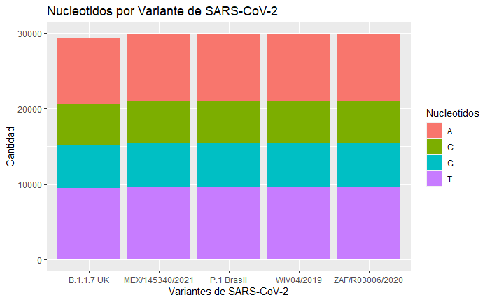

```r
library(tidyverse);
data %>%       rownames_to_column() %>%        pivot_longer(-rowname) %>%       ggplot(aes(rowname, value, fill = name)) +       geom_col() + xlab("Variantes de SARS-CoV-2") + ylab("Cantidad") + labs(title = "Nucleotidos por Variante de SARS-CoV-2", fill = "Nucleotidos")
```

Asimismo, la mayoría de las variantes presentan discrepancias mínimas en los criterios establecidos para la investigación, sin embargo, es destacable considerar que la investigación estaba dirigida a analizar la cantidad de nucleótidos que se encuentran en las diferentes variantes y como difieren en cantidad, no en forma, por lo que se concluye que las mutaciones surgen a partir de la reorganización de nucleótidos, no necesariamente de la cantidad de estos.